# Comparison of post test student ratings between Control and Treatment Group using Wilcoxon Rank Sum and Wilcoxon Signed Rank Exact Test

Paolo G. Hilado

April 30, 2019

Scenario: A research team is doing an experiment to assess whether there is a significant difference between the control and treatment group in the post test ratings of the students. The number of participants for each group were determined via sample size estimation using power and mean, and randomization is considered in the assignment of groups.

## Load the data set

```r
library(xlsx)
data <- read.xlsx("Experiment1.xlsx", sheetIndex = "Sheet1")
```

## Check the first and last 6 rows, structure of the data and generate a summary

```r
head(data)
```

```
##     Pre  Post Group
## 1  2.03 17.23 Cntrl
## 2  4.02 16.04 Cntrl
## 3 14.34 19.22 Cntrl
## 4 15.55 19.45 Cntrl
## 5  2.05 18.53 Cntrl
## 6 11.07 21.00 Cntrl
```

```r
tail(data)
```

```
##      Pre  Post Group
## 69 17.32 19.67    Tx
## 70  8.95  6.86    Tx
## 71  8.34 17.63    Tx
## 72 17.52 18.84    Tx
## 73  5.21 15.11    Tx
## 74  3.73 19.07    Tx
```

```r
str(data)
```

```
## 'data.frame':    74 obs. of  3 variables:
##  $ Pre  : num  2.03 4.02 14.34 15.55 2.05 ...
##  $ Post : num  17.2 16 19.2 19.4 18.5 ...
##  $ Group: chr  "Cntrl" "Cntrl" "Cntrl" "Cntrl" ...
```

```r
summary(data)
```

```
##       Pre             Post          Group
##  Min.   : 0.37   Min.   : 5.28   Length:74
##  1st Qu.: 5.48   1st Qu.:16.05   Class :character
##  Median :11.67   Median :18.20   Mode  :character
##  Mean   :10.93   Mean   :16.92
##  3rd Qu.:15.74   3rd Qu.:19.16
##  Max.   :19.77   Max.   :21.04
```

## Create subsets by test administration and groups

```r
#Retrieve Pretest ratings from Control Group
CntrlPre <- data[data$Group =="Cntrl",]$Pre
#Retrieve Pretest ratings from Treatment Group
TxPre <- data[data$Group == "Tx",]$Pre
#Retrieve PostTest ratings from Control Group
CntrlPost <- data[data$Group == "Cntrl",]$Post
#Retrive PostTest ratings from Treatment Group
TxPost <- data[data$Group == "Tx",]$Post
```

# Test for Normality with Anderson-Darling

```r
library(nortest)
nordata <- cbind(CntrlPre, CntrlPost, TxPre, TxPost)
apply(nordata, 2, function(x) ad.test(x))
```

```
## $CntrlPre
##
##  Anderson-Darling normality test
##
## data:  x
## A = 0.75109, p-value = 0.04608
##
##
## $CntrlPost
##
##  Anderson-Darling normality test
##
## data:  x
## A = 2.4165, p-value = 3.078e-06
##
##
## $TxPre
##
##  Anderson-Darling normality test
##
## data:  x
## A = 0.83981, p-value = 0.02754
##
##
## $TxPost
##
##  Anderson-Darling normality test
##
## data:  x
## A = 1.9828, p-value = 3.726e-05
```

## Generate Probability Density Function Plots

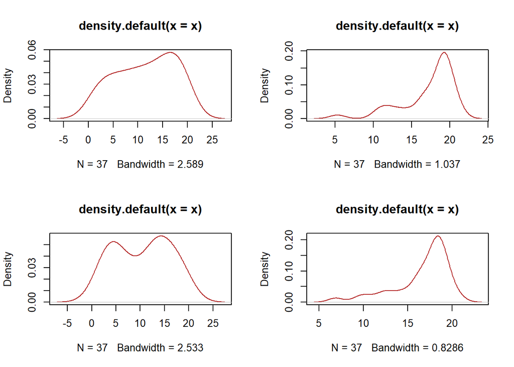

```r
par(mfrow=c(2,2))
apply(nordata, 2, function(x) plot(density(x), col = "firebrick"))
```

```r
# Checking both the statistics and visualizations, it seems that the data set is not approximately normally distributed.
```

## Generate Descriptive Statistics

```r
library(psych)
describeBy(data$Pre, data$Group) #Median is the measure for central tendency given the result of normality test
```

```
##
##  Descriptive statistics by group
## group: Cntrl
##    vars  n  mean   sd median trimmed  mad  min  max range  skew kurtosis   se
## X1    1 37 11.48 5.92  11.65   11.68 8.35 1.37 19.7 18.33 -0.25    -1.33 0.97
## ------------------------------------------------------------
## group: Tx
##    vars  n  mean   sd median trimmed  mad  min   max range  skew kurtosis   se
## X1    1 37 10.37 5.79  11.69   10.35 7.99 0.37 19.77  19.4 -0.05    -1.43 0.95
```

```r
describeBy(data$Post, data$Group) #Median is the measure for central tendency given the result of normality test
```

```
##
##  Descriptive statistics by group
## group: Cntrl
##    vars  n  mean   sd median trimmed  mad  min   max range  skew kurtosis   se
## X1    1 37 17.23 3.52  19.05   17.67 1.44 5.28 21.04 15.76 -1.47     1.77 0.58
## ------------------------------------------------------------
## group: Tx
##    vars  n  mean   sd median trimmed  mad  min   max range  skew kurtosis   se
## X1    1 37 16.62 3.17  17.63   17.03 1.96 6.86 20.83 13.97 -1.32      1.1 0.52
```

# Test for Sig. Diff. in Pretest ratings of Control and Treatment

```r
wilcox.test(CntrlPre, jitter(TxPre), alternative = "two.sided", paired = FALSE) # There is no significant difference in the pretest ratings between Control and Treatment. This is consistent with the expectations of an experimental design.
```

```
##
##  Wilcoxon rank sum exact test
##
## data:  CntrlPre and jitter(TxPre)
## W = 758, p-value = 0.4323
## alternative hypothesis: true location shift is not equal to 0
```

# Test for Sig. Diff. in Pretest and Posttest ratings of Control Group

```r
wilcox.test(CntrlPre, jitter(CntrlPost), alternative = "two.sided", paired = TRUE) # Presence of significant difference in pretest and post test ratings of the Control Group indicate that an increase in ratings in the Post Test may be attributed by other factors beside chance. This makes the findings rather intriguing considering the change in ratings despite the fact that it occured in the Control Group; one that was not introduced with Treatment.
```

```
##
##  Wilcoxon signed rank exact test
##
## data:  CntrlPre and jitter(CntrlPost)
## V = 31, p-value = 3.456e-08
## alternative hypothesis: true location shift is not equal to 0
```

# Test for Sig. Diff. in Pretest and Posttest ratings of Treatment Group

```r
wilcox.test(TxPre, jitter(TxPost), alternative = "two.sided", paired = TRUE) # There exists a significant difference in the pretest and post test ratings for the Treatment group which somehow indicates that the change may be related to the introduction of the treatment rather than chance. However, this is questionable considering the observation in the Control group wherein there is an increase in ratings despite the fact that there was no treatment introduced.
```

```
##
##  Wilcoxon signed rank exact test
##
## data:  TxPre and jitter(TxPost)
## V = 25, p-value = 1.315e-08
## alternative hypothesis: true location shift is not equal to 0
```

# Test for Sig. Diff. in PostTest ratings of Control and Treatment Group

```r
wilcox.test(CntrlPost, jitter(TxPost), alternative = "two.sided", paired = FALSE) # When comparing the Post Test ratings of Control and Treatment Group, no significant difference is observed. This further explains the observations made earlier.
```

```
##
##  Wilcoxon rank sum exact test
##
## data:  CntrlPost and jitter(TxPost)
## W = 842, p-value = 0.08972
## alternative hypothesis: true location shift is not equal to 0
```

## It can be noted that the introduction of the treatment does not necessarily lead to improvement in ratings given that there is no significant difference in the post test ratings of the Control and Treatment group; any difference observed may simply be attributed to chance. Although a significant increase in ratings can be noted between the Pre and Post Test of the Treatment Group, it may be inaccurate to attribute this to the treatment knowing that such significant increase is also observed in the Pre and Post Test ratings of the Control Group.